# Analyse Bivariée

06 janvier 2020

## Introduction générale

## Sources et Reférences

- Ce cours reprend le cheminement du cours M2 IGAST 2017 d'Élodie Buard
- R et espace https://framabook.org/r-et-espace/
- Probabilités, analyse de données et statistiques , Gilbert Saporta, Editions TECHNIP, 2011
- Nombreuses ressources en ligne : http://www.foad-mooc.auf.org/IMG/pdf/424B_-Application_des_methodes_statistiques_d_analyse.pdf
- et wikipedia !

## Deux familles statistiques

### Statistiques **inférentielles**

Pour répondre à la question : «A partir d'un échantillon , que peut-on attendre (inférer) de la population ?»

- Modèles, estimateurs, … : **régression**, **estimation**, **extrapolation**
- *Liaisons* statistiques : **corrélation**, **covariance**
- test statistiques, notions de probabilités
- e.g. sondages, rencensement, intervalle de confiance , prédictions, …

## Deux familles statistiques

### Statistiques **descriptives**

Pour **résumer**, **synthétiser**, rendre intelligible, les propriétés d'une **population** à partir des **variables** qui décrivent les individus et la **répartition** de leurs valeurs.

- Graphiques (histogrammes, boxplots, )
- Mesures (fréquences , distributions , moments)
- classification, ACP,…

## Vocabulaire

### Population

**Ensemble** d'individus

"données", "corpus", "échantillon", "data"

### Individu

Unité statistique **élémentaire**: un individu,

"les lignes du tableau"

## Vocabulaire

### Variables

**Caractéristiques, propriétés** d’un individu, **mesurées** par des enquêtes, des observations…

"les colonnes du tableau"

- **Qualitatives** : facteurs, classes , catégories, e.g. Sexe, CSP, type ; on parle de **modalité**
- **Quantitatives** : nombres e.g. Âge, taille, revenu, surface

⚠ **Valeurs** et **Nature** de données sont deux choses distinctes.

3≠trois≠III

⚠ Valeurs manquantes

NA , NaN, Null

## L'objet du cours : l' Analyse Bivariée

Objectif : **Analyser** le **lien** entre deux variables

- **2 variables quantitatives**

"nombre d'habitants et nombre de lignes de bus par département"

"nombre de lignes de bus en 1998 et en 2018"

- **2 variables qualitatives**

"couleur des yeux et port de lunettes"

- **Une variable quantitative, une variable qualitative**

"taille et couleur des yeux"

## Mise en garde

⚠ Une liaison, même très forte, entre deux variables, n'indique pas la causalité! ⚠

Erreur très courrante, très tentante.

[figure not shown]

© TylerVigen http://tylervigen.com/spurious-correlations

## Analyse bivariée avec des données spatiales

### Données "non spatiales""

Les variables sont des valeurs attributaires d'individus, leurs localisation n'est pas prise en compte

### Données spatiales

Individus restreints spatialement (selection spatiale), ou variables de provenance géographique (e.g. Lieu de résidence) renseignées pour les individus

quid des **distances** ? \(\rightarrow\) modèle gravitaire , réseau etc.

### Données localisées

Auto-corrélation spatiale (Moran's I) Geographicaly Weightd Regression (GWR)

## Lien entre deux variables quantitatives

## Première étape

Toujours en premier: Regarder l'aspect des données avec des graphiques ("exploration visuelle")

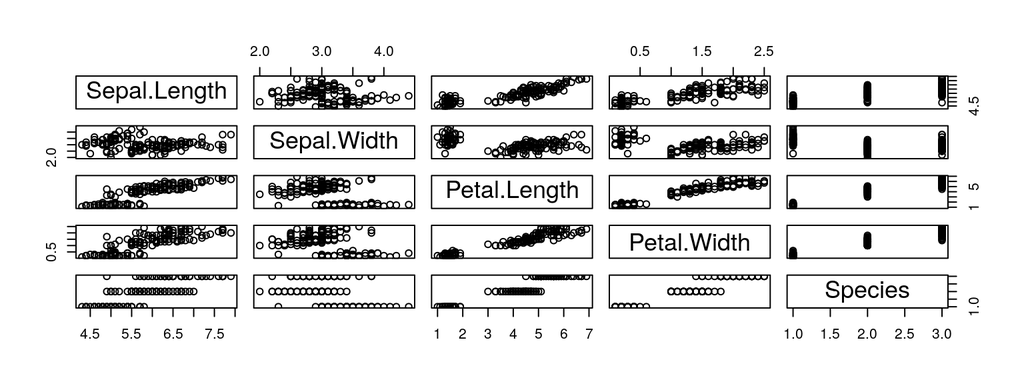

```r
data(iris)
plot(iris)
```

Existe-t-il un lien entre des variables ?

## Forme des dépendances

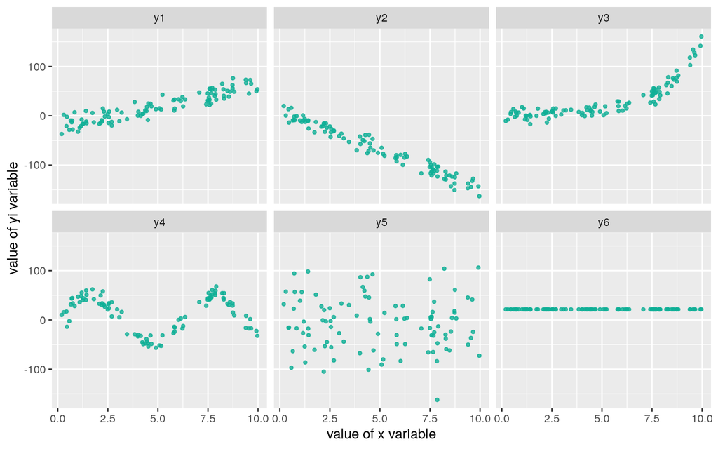

## Les étapes

1. Tracer le nuage de points
2. Existe-t-il une liaison ?
3. Est-elle de forme linéaire ? De quel sens ?
4. Si la liaison est de forme linéaire \(\rightarrow\) faire une **régression**
5. Si la liaison est non linéaire, est-elle monotone ? De forme connue ?\(\rightarrow\) Proposer un **modèle**

5bis. Tenter un modèle **LOESS** avec prudence (uniquement descriptif , aucun pouvoir de généralisation) cf le blog de Lise Vaudor [http://perso.ens-lyon.fr/lise.vaudor/regression-loess/]

## Régression linéaire

Si la forme du nuage de points s'y prête, on peut faire une **régression linéaire** (ou **ajustement** linéaire).

On cherche la droite qui «passe au mieux» (=*ajustée*) dans le nuage de points formés par le tracé de deux variables quantitatives \(Var1\) et \(Var2\) qui permet de vsiualiser:

- l'**intensité** du lien / de la dépendance : points proche de la droite ou non ?
- la **forme** de la dépendance : linéaire ou non ?
- le **sens** de la dépendance : nulle, positive ou négative ?

## Régression linéaire

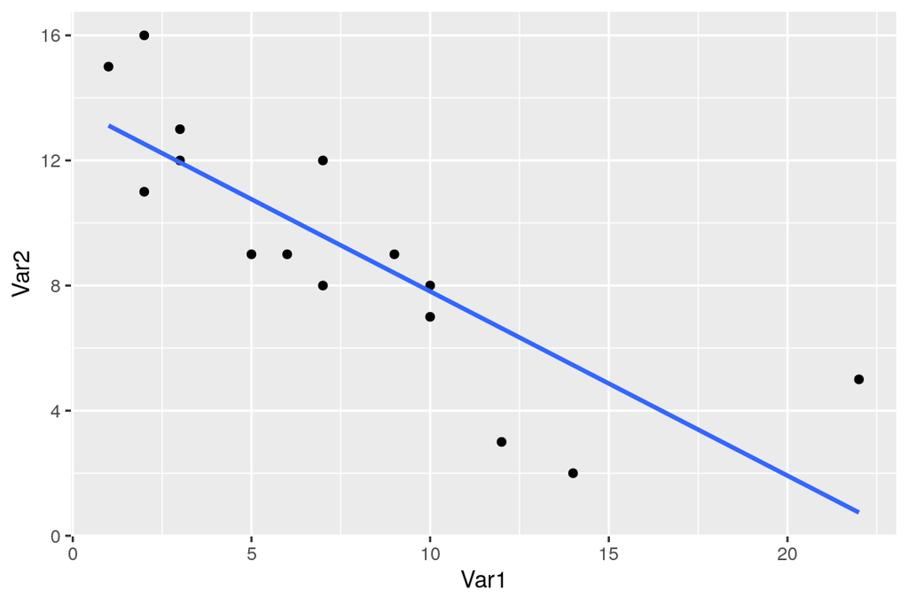

«Droite qui passe au mieux» = qui minimise la **somme des écarts quadratiques** entre la droite et les points du nuage.

## Régression linéaire : le modèle

L'**équation** de la droite est un **modèle linéaire** de la relation statistique qui lie \(V1\) et \(V2\); on dit que \(V1\) **explique** \(V2\) :

Notre modèle :

\(V2=aV1+b\)

Si la régression linéaire est correcte, alors pour un individu \(i\) dont on connait \(V1_i\), on infère la valeur \(V2_i\) par le modèle : \(V2_i = a \times V1_i +b\)

\(\implies\)Comment déterminer qu'une régression linéaire est «correcte» ?

## le \(R^2\)

\(R^2 \in [0;1]\) , coefficient de détermination linéaire .

Donne la **qualité de prédiction** de la régression.

"Proche de 1"" \(\equiv\) "très bonne qualité"

C'est le pourcentage de variation de \(V_2\) expliqué par la variation de \(V_1\)

C'est aussi le carré de la corrélation \(cor(V_1,V_2)\) (celle donnée par le \(r\) de Pearson)

\(R^2 = 1 - \frac{\sum_{i=1}^{n} (y_i - \hat{y})^2}{\sum_{i=1}^{n} (y_i - \bar{y})^2}\)

## Format des resultats de `lm` avec R

```r
summary(lm(iris$Petal.Length~iris$Petal.Width))
```

```
##
## Call:
## lm(formula = iris$Petal.Length ~ iris$Petal.Width)
##
## Residuals:
##      Min       1Q   Median       3Q      Max
## -1.33542 -0.30347 -0.02955  0.25776  1.39453
##
## Coefficients:
##                  Estimate Std. Error t value Pr(>|t|)
## (Intercept)       1.08356    0.07297   14.85   <2e-16 ***
## iris$Petal.Width  2.22994    0.05140   43.39   <2e-16 ***
## ---
## Signif. codes:  0 '***' 0.001 '**' 0.01 '*' 0.05 '.' 0.1 ' ' 1
##
## Residual standard error: 0.4782 on 148 degrees of freedom
## Multiple R-squared:  0.9271, Adjusted R-squared:  0.9266
## F-statistic:  1882 on 1 and 148 DF,  p-value: < 2.2e-16
```

Distribution des résidus, coefficients du modèle ajusté et leur **p-value** associée (ici sur un test de Student, notée `Pr(>|t|)` et \(R^2\))

## Comment evaluer la "validité" du modèle linaire ?

En pratique, il faut réunir deux critères :

- des coefficients avec des p-values associées faibles (e.g. <0.05) \(\leftrightarrow\) "on a peu de chances de se tromper"
- un \(R^2\) élevé \(\leftrightarrow\) "le modèle prédit bien les observations"

## la p-value

Elle peut s'interpréter comme la probabilité d'avoir un résultat identique tout en conservant l'hypothèse nulle.

Ici , l'hypothèse nulle est "les deux séries sont indépendantes".

On peut grossièrement considérer que p-value = pourcentage de chances de se tromper en rejetant l'hypothèse nulle, c'est à dire en considérant que les deux séries ne sont pas indépendantes et qu'il existe une relation (ici, linéaire car nous testons le coefficient de coorélation linéaire) entre les deux.

Rappel : - conserver \(H_0\) : considérer les deux variables comme indépendantes - rejeter \(H_0\) : considérer les deux variables comme ayant une relation statistique, un lien.

## Bonus: Critères de significativité du lien linéaire

Les **résidus** \(\epsilon_i\) (écart entre valeur observée et valeur prédite par le modèle pour l'individu \(i\)) doivent:

- être indépendants : \(cov(x_i, \epsilon_i) = 0\)
- être distribués selon un loi normale de moyenne nulle \(\mathscr{N}(0,\sigma_{\epsilon})\)
- être distribués de façon homogène (homoscédasticité), i.e. de variance constante \(var(\epsilon_i)=\sigma_{\epsilon}^2\) , indépendante de l'observation

## Bonus: Evaluation de l'indépendance des résidus avec R

Graphique de la fonction `acf`: Si une barre exceptée la première dépasse la ligne en pointillés, on peut remettre en cause l'indépendance des résidus. Ici, c'est le cas.

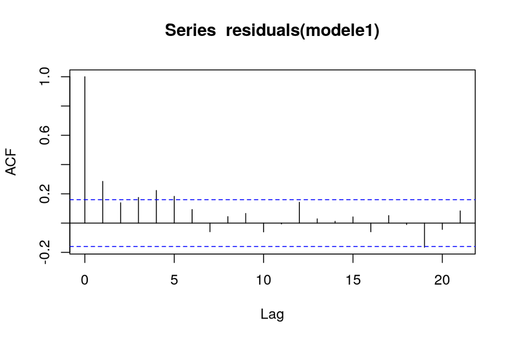

```r
modele1 <- lm(iris$Petal.Length~ iris$Petal.Width)
acf(residuals(modele1))
```

## Bonus:Les 4 graphiques résultats de la fonction `lm`

La fonction `lm` de R et ses résultats permettent de tracer 4 graphiques pour évaluer certains des critères de significativité.

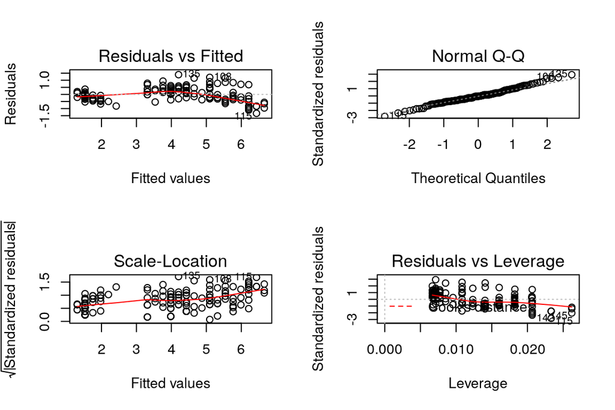

```r
modele1 <- lm(iris$Petal.Length~ iris$Petal.Width)
par(mfrow=c(2,2)) # pour avoir une matrice de grpahes
plot(modele1)
```

## Bonus: Évaluer l'homogénéité des résidus avec R

Premier graphique : pour vérifier que le nuage de points est homogène (e.g. pas de relation non-linéaire entre résidus et valeurs prédites)

Une éventuelle relation non-linéaire pourrait se retrouver dans les résidus.

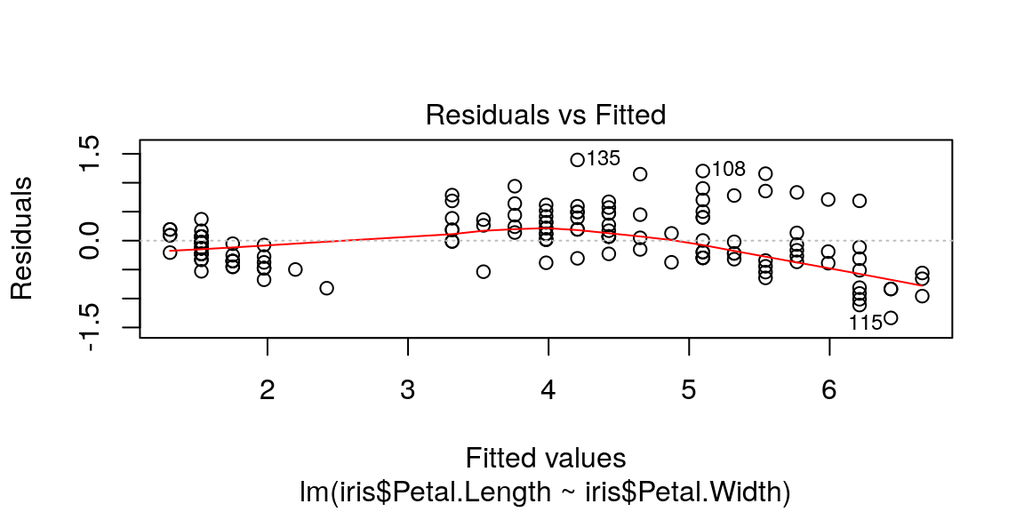

```r
modele1 <- lm(iris$Petal.Length~ iris$Petal.Width)
plot(modele1,1)
```

Ici : légère structure parabolique

## Bonus: Evaluer la normalité de la distribution des résidus avec R

Le deuxième graphique "Q-Q plot" : pour vérifier l'**hypothèse de normalité des résidus**, les points doivent être proches de la bissectrice

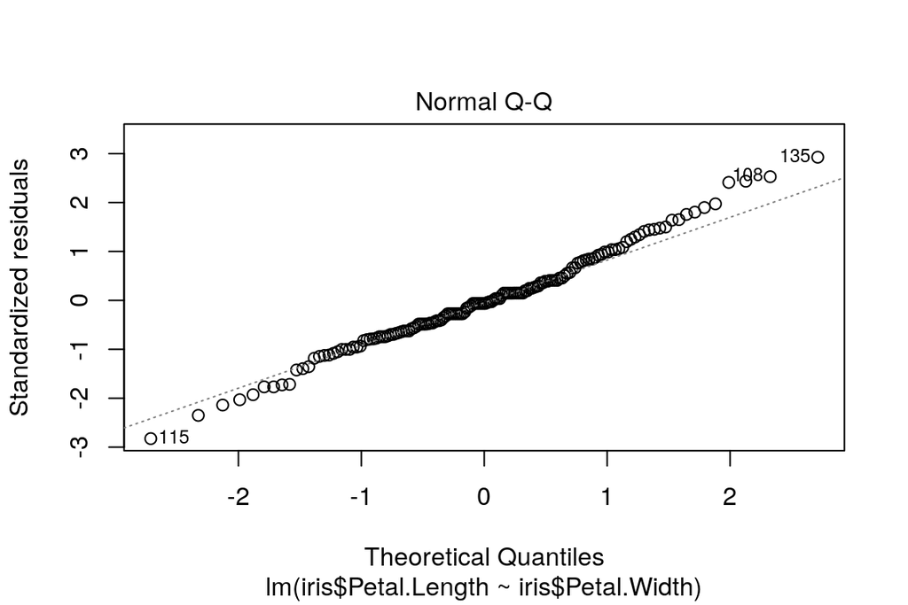

```r
modele1 <- lm(iris$Petal.Length~ iris$Petal.Width)
plot(modele1,2)
```

## Bonus: Evaluer l'homoscédasticité des résidus

Le troisème graphique "Scale location" : si les résidus sont distribués de façon homogène suivant les valeurs "fittées", alors la droite est plutôt horizontale et les points sont disposés de façon homogène autour.

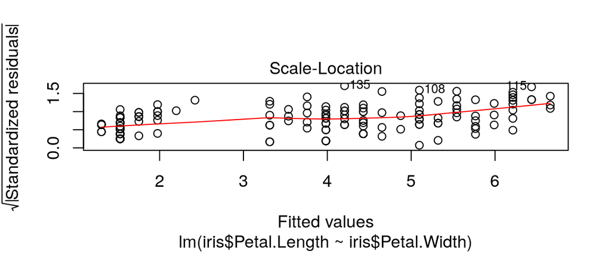

```r
modele1 <- lm(iris$Petal.Length~ iris$Petal.Width)
plot(modele1,3)
```

Ici: légère pente mais les points sont distribués de façon relativement homogène autour de la droite.

## Corrélation de deux variables avec R

Pour étudier l'intensité d'un lien statistique linéaire entre 2 variables

```r
cor(iris$Petal.Length, iris$Petal.Width)
```

```
## [1] 0.9628654
```

`cor(x,y)` donne le **coefficient de corrélation** \(\in [-1;1]\) entre deux variables x et y (e.g. colonnes d'un dataframe) .

- +1 : les deux variables croissent ou décroissent conjointement
- -1 : quand l'une des variables croît, l'autre décroît.
- 0 : pas de relation **linéaire** entre les deux variables

R donne le coefficient de Pearson par defaut, l'argument `method` de la fonction `cor()` permet de spécifier deux autres coefficients : Kendall et Spearman.

## Test de corrélation entre deux variables avec R

Version plus complète : c'est un **test**, on a plusieurs indicateurs statistiques sur ce test, notamment la **p-value** et **l'intervalle de confiance**

```r
cor.test(iris$Petal.Length, iris$Petal.Width)
```

```
##
##  Pearson's product-moment correlation
##
## data:  iris$Petal.Length and iris$Petal.Width
## t = 43.387, df = 148, p-value < 2.2e-16
## alternative hypothesis: true correlation is not equal to 0
## 95 percent confidence interval:
##  0.9490525 0.9729853
## sample estimates:
##       cor
## 0.9628654
```

Rappel : la p-value quantifie la **significativité** du test. En général, on considère le test significatif si elle est en dessous de 5%, soit 0.05.

## Calcul direct du coefficient de corrélation

Soient deux variables \(V_1\) et \(V_2\)

Le coefficient de corrélation \(r\) de \(V_1\) et \(V_2\) est la normalisation de la covariance par le produit des écart-types des variables

\(r= \frac{cov(V_1,V_2)}{\sigma_{V_1}\sigma_{V_2}}\)

Rappel : La covariance est la moyenne du produit des écarts à la moyenne

\(cov(V_1,V_2)= E[(V_1-E[V_1])(V_2-E[V_2])]\)

## Matrice de corrélations

```r
cor(iris[,1:4])
```

```
##              Sepal.Length Sepal.Width Petal.Length Petal.Width
## Sepal.Length    1.0000000  -0.1175698    0.8717538   0.8179411
## Sepal.Width    -0.1175698   1.0000000   -0.4284401  -0.3661259
## Petal.Length    0.8717538  -0.4284401    1.0000000   0.9628654
## Petal.Width     0.8179411  -0.3661259    0.9628654   1.0000000
```

Présentation des corrélations entre les variables quantitatives d'un tableau, pour tous les couples de variables.

La matrice de corrélation est symmétrique, et sa diagonale est constituée de 1.

## Sensibilité aux 'outliers'

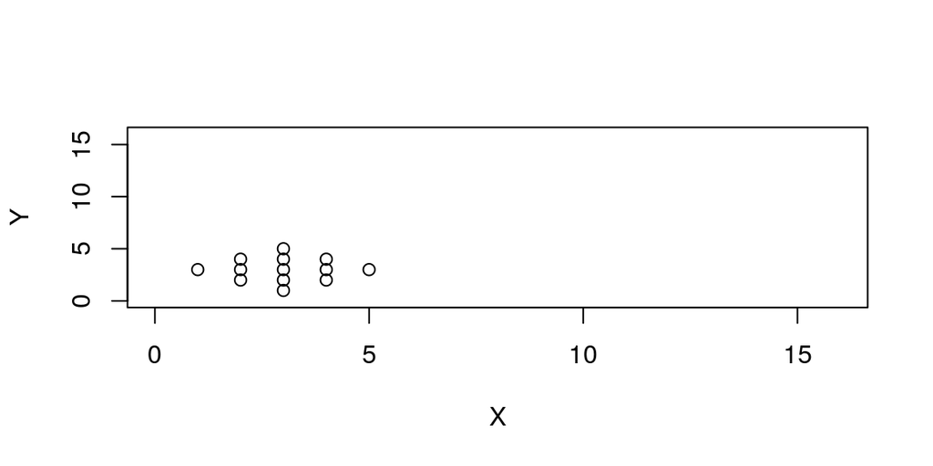

```r
X <-  c(3,2,3,4,1,2,3,4,5,2,3,4,3)
Y <-  c(1,2,2,2,3,3,3,3,3,4,4,4,5)
plot(X, Y, xlim = c(0,16), ylim= c(0,16))
```

```r
cor.test(X,Y)$estimate
```

```
## cor
##   0
```

## Sensibilité aux 'outliers'

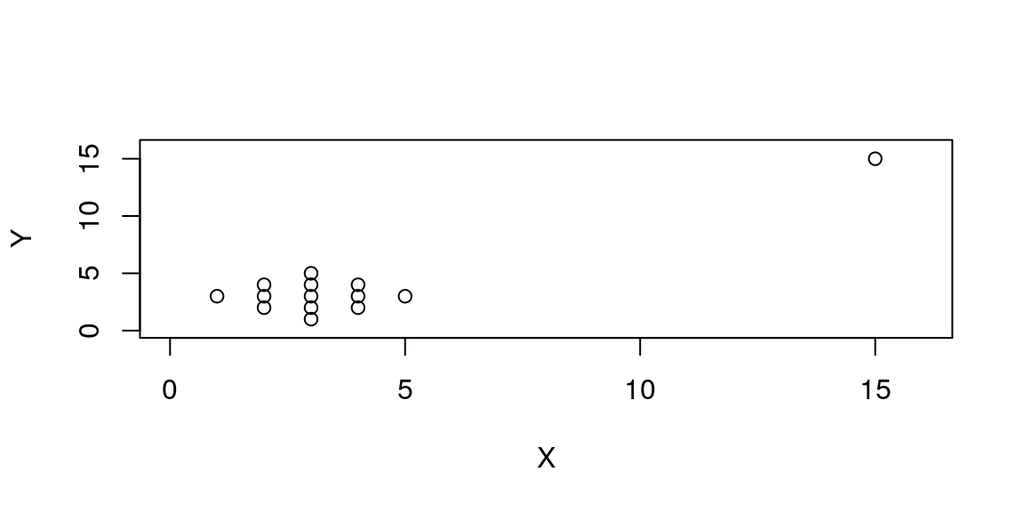

```r
X <-  c(3,2,3,4,1,2,3,4,5,2,3,4,3,15)
Y <-  c(1,2,2,2,3,3,3,3,3,4,4,4,5,15)
plot(X, Y, xlim = c(0,16), ylim= c(0,16))
```

```r
cor.test(X,Y)$estimate
```

```
##       cor
## 0.9052224
```

## Sensibilité aux 'outliers'

Outlier : observation "*anormale*", par sa valeur extrème , comparée aux autres.

La corrélation et la régression linéaire sont très sensibles aux outliers.

\(\rightarrow\) s'interroger sur la nécessité de nettoyer/filter les données et des conséquences

## Regression linéaire avec R

Fonction `lm()` , modèle de la forme `réponse ~ termes`

```r
my_model <- lm(Petal.Width~Petal.Length, iris)
summary(my_model)
```

```
##
## Call:
## lm(formula = Petal.Width ~ Petal.Length, data = iris)
##
## Residuals:
##      Min       1Q   Median       3Q      Max
## -0.56515 -0.12358 -0.01898  0.13288  0.64272
##
## Coefficients:
##               Estimate Std. Error t value Pr(>|t|)
## (Intercept)  -0.363076   0.039762  -9.131  4.7e-16 ***
## Petal.Length  0.415755   0.009582  43.387  < 2e-16 ***
## ---
## Signif. codes:  0 '***' 0.001 '**' 0.01 '*' 0.05 '.' 0.1 ' ' 1
##
## Residual standard error: 0.2065 on 148 degrees of freedom
## Multiple R-squared:  0.9271, Adjusted R-squared:  0.9266
## F-statistic:  1882 on 1 and 148 DF,  p-value: < 2.2e-16
```

## Que faire lorsque la relation n'est pas linéaire ?

Quand les deux variables sembles corrélées , de façon **monotone** mais **non linéaire**,

\(\rightarrow\) Coefficient de **Spearman**, basé sur le **rang** des individus.

\(\rho = 1 - \frac{6\sum_{i=1}^{n}(rg(X_i)-rg(Y_i))^2 }{n^3 -n}\)

avec :

\(rg(X_i)\) le *rang* de \(X_i\) (le classement de sa valeur) dans la distribution de \(X\)

\(n\) le nombre d'individus

## Obtenir le coefficient Spearman avec R

```r
cor.test(iris$Sepal.Length, iris$Sepal.Width, method="spearman", exact = FALSE)
```

```
##
##  Spearman's rank correlation rho
##
## data:  iris$Sepal.Length and iris$Sepal.Width
## S = 656280, p-value = 0.04137
## alternative hypothesis: true rho is not equal to 0
## sample estimates:
##        rho
## -0.1667777
```

l'argument `exact` doit être précisé en cas de valeurs ex aequo dans les données.

## Utilisation conjointe des coefficients de Pearson et Spearman

\(r\) (Pearson) et \(\rho\) (Spearman) sont deux moyens d'estimer la corrélation: lequel choisir ?

si \(r = \rho\): on garde \(r\) (plus simple)

si \(r < \rho\): la relation est non-linéaire : prendre \(\rho\)

si \(r > \rho\): il y a un biais, prendre \(\rho\) (plus robuste)

… et toujours **tracer le nuage de points** pour examiner la nature de la relation.

## Linéariser des relations non-linéaires

## Relation log-linéaire

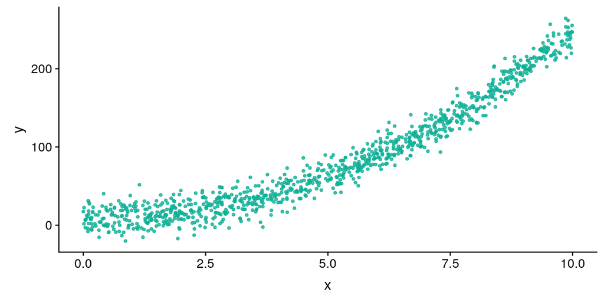

Relation de type \(y=ax^b\)

se linéarise par \(ln(y)=aln(x) + ln(b)\)

## Relation géométrique (exponentielle)

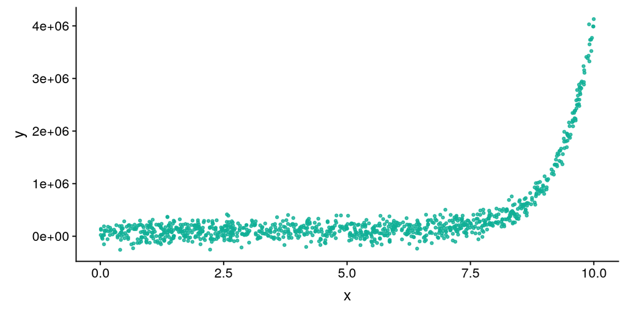

Relation de type \(y=e^{ax+b}\)

se linéarise par \(ln(y)=ax + ln(b)\)

## Relation logarithmique

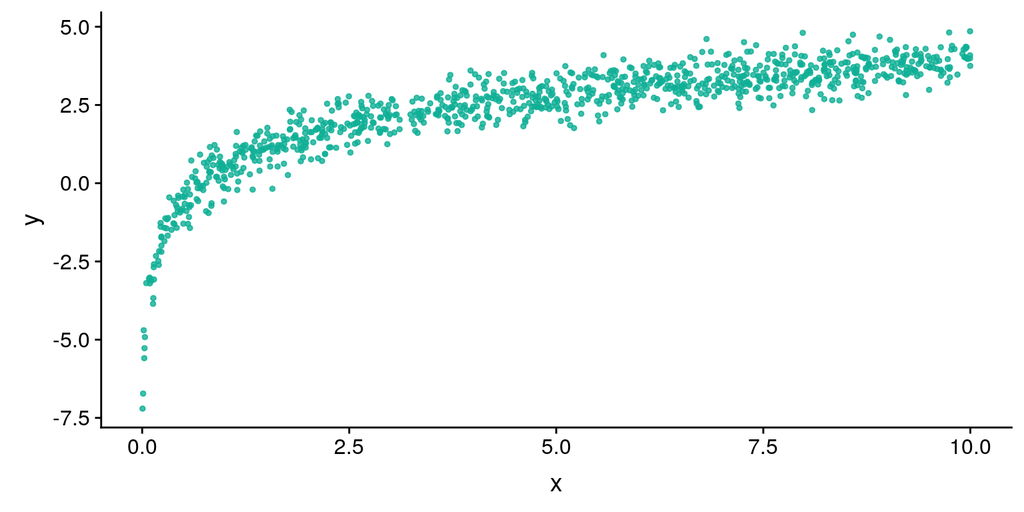

Relation de type \(y=a*ln(x)+b\)

\(\rightarrow\) changement de variable !

## Relation logistique

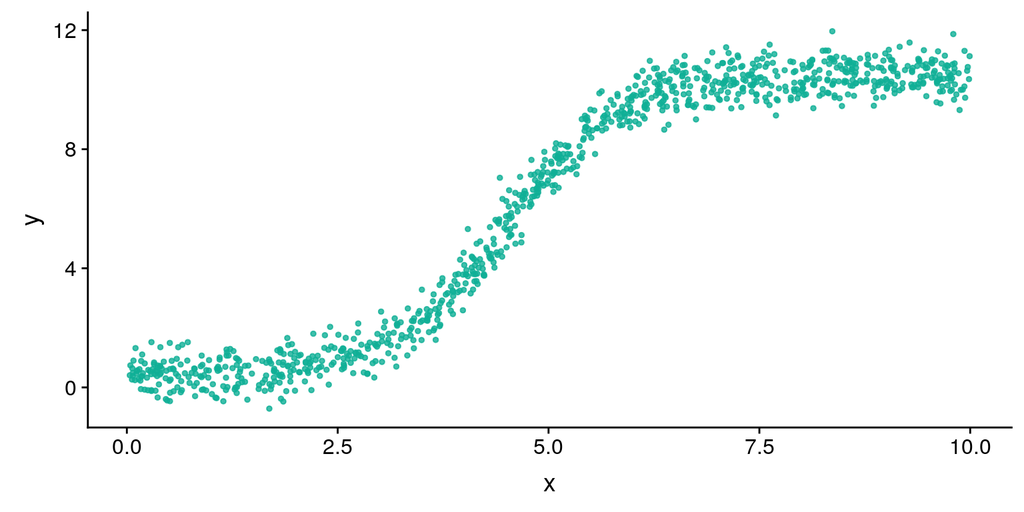

Relation de type \(y= y_{min} * \frac{y_{max}-y_{min}}{1+e^{ax+b}}\)

se linéarise par \(ln\bigg(\frac{y_{max}-y}{y-y_{min}}\bigg)=ax+b\)

## Lien entre deux variables qualitatives

## Représentation graphique

Pour deux variables qualitatives, on ne peut pas produire de nuages de points, ni de droite de régression.

\(\rightarrow\) on peut représenter la table de contingence (cf. fonction `mosaicplot` de R).

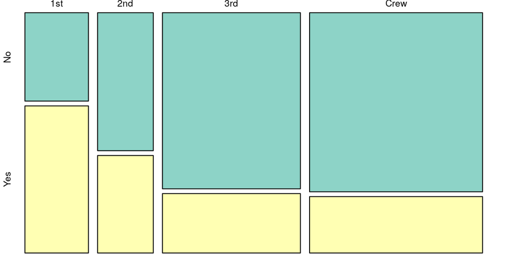

## Test statistique dit du "Chi 2"" ou "Chi carré""

Le test du \(\chi ^2\) est un test d'indépendance, il mesure l'**écart**, la différence, entre deux distributions de **variables qualitatives**

Il répond à la question : "Existe-t-il un lien statistique entre deux séries de valeurs qualitatives"

(La réponse est de type OUI/NON , le \(\chi^2\) ne donne pas l'**intensité** du lien)

## Test statistique dit du "Chi 2"" ou "Chi carré""

- Hypothèse nulle \(H_0\) : les deux distributions sont indépendantes.
- «faire le test» permet de conserver ou de rejeter cette hypothèse

Principe:

- On génère une **distribution théorique** à laquelle on va comparer la **distribution observée**.
- Cette distribution théorique reflête ce qui se passerait si on suppose que \(H_0\) est vraie
- Avec cette comparaison, on pourra rejeter ou conserver l'hypothèse nulle.

La construction de cette distribution se fait à partir du **tableau de contingence**

## Tableau de contingence

C'est un tableau à double entrée qui croise deux **variables qualitatives**.

Dans une case on trouve l'effectif des individus caractérisés par la conjonction des modalités en ligne et en colonnes.

Exemple sur des formes géométriques de couleurs :

\[\begin{array}{c|c|c} & blanc & noir \\ \hline carré & 22 & 12 \\ \hline rond & 10 & 30 \\ \hline triangle & 26 & 5 \\ \end{array}\]

Dans R : fonction `table`

## Construction de la distribution théorique.

On commence par sommer les effectifs selon les modalités (en ligne et en colonne)

\[\begin{array}{c|c|c|c} & blanc & noir & \texttt{total}\\ \hline carré & 22 & 12 & 34\\ \hline rond & 10 & 30 & 40 \\ \hline triangle & 26 & 5 & 31\\ \hline \texttt{total} & 58 & 47 & 105 \end{array}\]

On appelle les sommes en lignes et en colonnes **sommes marginales**, elles sont mises dans les "marges" du tableau.

## Construction de la distribution théorique

En divisant par la taille de l'effectif, on obtient les **fréquences observées**.

\[\begin{array}{c|c|c|c} & blanc & noir & \texttt{total}\\ \hline carré & 0.20952381& 0.11428571 & 0.3238095\\ \hline rond & 0.09523810 & 0.28571429 & 0.3809524 \\ \hline triangle & 0.24761905 & 0.04761905 & 0.2952381\\ \hline \texttt{total} & 0.552381 & 0.447619 & 1 \end{array}\]

On obtient les **pourcentages de l'effectif** dans les cases du tableau.

C'est également la **probabilité** dans cette population, qu'un individu soit caractérisé par les modalités en ligne et en colonne.

## Construction de la distribution théorique

\[\begin{array}{c|c|c|c} & blanc & noir & \texttt{total}\\ \hline carré & 0.20952381& 0.11428571 & \textbf{0.3238095}\\ \hline rond & 0.09523810 & 0.28571429 & \textbf{0.3809524} \\ \hline triangle & 0.24761905 & 0.04761905 & \textbf{0.2952381}\\ \hline \texttt{total} & \textbf{0.552381} & \textbf{0.447619} & 1 \end{array}\]

De la même façon, les **fréquences marginales**, donnent la **probabilité** d'observer un individu de la modalité correspondant à la ligne ou à la colonne considérée.

Exemple : dans cette population , j'ai 29.5% de chances de tirer un triangle

## Construction de la distribution théorique

Rappel : Probabilité conjointe de deux évènements \(A\) et \(B\) **indépendants**  
\(P(A \cap B) = P(A) \times P(B)\)

A partir des **fréquences marginales** précédentes, on obtient pour chaque couple de modalités la probabilité **théorique**, celle qui suppose \(H_0\), i.e. l'indépendance des deux variables, par un simple produit.

Exemple : Si \(H_0\) est vraie, la probabilité d'observer un triangle noir est donnée par:

\(P(triangle \cap noir) = P(triangle) \times P(noir)\)

\(P(triangle \cap noir) =0.447619 \times 0.2952381 = 0.1321542\)

La probabilité théorique d'observer un triangle noir est de 13,2%

## Construction de la distribution théorique

On crée un second tableau, dont chaque case vaut le produit des fréquences marginales calculées sur le tableau des observations.

\[\begin{array}{c|c|c|c} & blanc & noir & \texttt{total}\\ \hline carré & 0.1788662 & 0.1449433 & \textbf{0.3238095}\\ \hline rond & 0.2104309 &0.1705215 & \textbf{0.3809524} \\ \hline triangle & 0.1630839 & 0.1321542 & \textbf{0.2952381}\\ \hline \texttt{total} & \textbf{0.552381} & \textbf{0.447619} & 1 \end{array}\]

C'est le tableau des **fréquences théoriques**.

## Tableau des effectifs théoriques

On l'obtient en multipliant les fréquences théoriques par la taille de la population observée (ici 105)

\[\begin{array}{c|c|c} & blanc & noir \\ \hline carré & 18.78095 & 15.21905 \\ \hline rond & 22.09524 & 17.90476 \\ \hline triangle & 17.12381 & 13.87619 \\ \end{array}\]

N.B. Il n'est pas nécessaire d'arrondir les effectifs théoriques

## Calcul du Chi 2

C'est la somme, pour chaque case du tableau de contingence, des écarts carrés entre effectif observé et effectif théorique, divisés par l'effectif théorique.

ici : \(\chi^2 = 26.30329\)

## Interprétation du Chi 2

Il faut comparé la valeur du \(\chi^2\) calculée avec la **valeur critique** qu'on trouve dans une **table de loi de Student** (ou table de loi du chi 2).

C'est un tableau à double entrée : une **valeur de quantile**, et un **degré de liberté**.

On peut considérer que la valeur de quantile est le pourcentage d'erreur qu'on s'autorise de faire. On prend souvent **5%** : la colonne 1-0.05 = 0.95

Le degré de liberté est obtenu en calculant la valeur \((nb\_lignes - 1)*(nb\_colonnes -1)\).

Dans notre exemple , le degré de liberté est 2*1 = 2

## Table de loi de Student

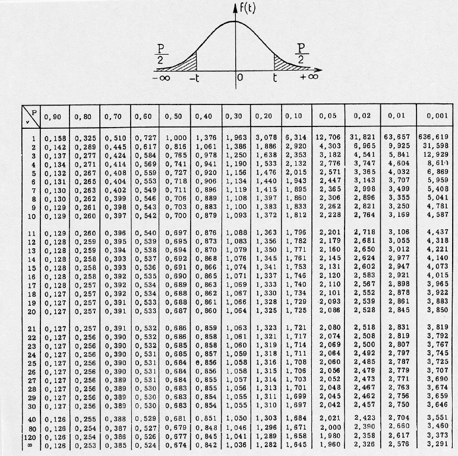

## Interprétation du Chi 2

D'après le tableau de la loi de Student , la valeur critique pour un test avec 5% de chances de se tromper est un degré de liberté de 2 vaut 4.303.

## Les étapes du \(\chi ^2\)

- Tableau de contingence
- Sommes marginales
  - Calcul des fréquences observées
  - Calcul des fréquences théoriques
- Tableau d'effectifs théoriques
- Calcul de la valeur du test
- Comparaison avec les valeurs de la table de Student

## Lien entre une variable qualitative et une variable quantitative.

## Représentation graphique.

Pas de moyen **simple** de calculer le lien entre une variable qualitative et une variable quantitative.

- corrélation de rang
- régression logistique
- analyse de la variance (ANOVA)

La variable qualitative sert de **catégorie**, on fait varier la représentation graphique de la variable quantitative suivant cette catégorie.

2 possibilités :

- boîtes à moustaches
- superposition d' histogrammes / densités

## Les boîtes à moustaches

"Boîte à moustaches", aussi appellées "boxplot", montre les quartiles d'une variable

Quartile = «quantile de 4», valeurs qui séparent une variable quantitative en quarts, i.e. paquets d'un quart de l'effectif

- Premier quartile : sépare les 25% inférieurs des valeurs
- Second quartile : **mediane**, sépare les 50% inférieurs des valeurs
- troisième quartile : sépare les 75% inférieurs des valeurs

Dans R, fonction `quantile`

## Boxplot et Distribution

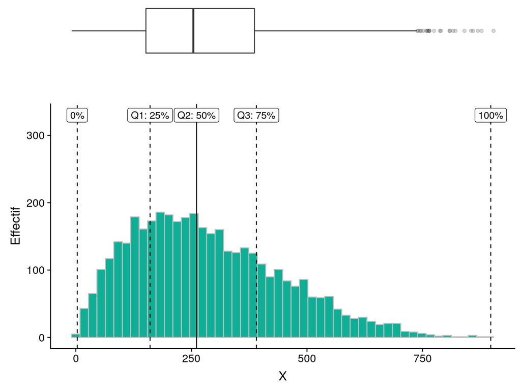

## Boxplot par catégories

Principe : on trace un boxplot par modalité de la variable qualitative.

E.g. : consommation de véhicules par type (dataset `mpg` de R)

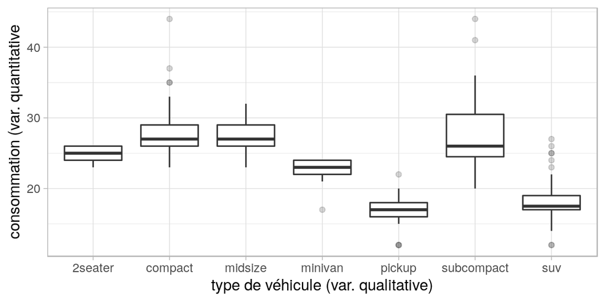

## Références supplémentaires

## Refs

Cours complet sur les modèles linéaires : [https://www.math.univ-toulouse.fr/~barthe/M1modlin/poly.pdf]

Interprétation des graphique de `lm` en R : [https://data.library.virginia.edu/diagnostic-plots/]